# Overview

Dataset info

| Number of variables | 68 |
| --- | --- |
| Number of observations | 66 |
| Total Missing (%) | 54.7% |
| Total size in memory | 35.2 KiB |
| Average record size in memory | 545.9 B |

Variables types

| Numeric | 12 |
| --- | --- |
| Categorical | 25 |
| Boolean | 4 |
| Date | 0 |
| Text (Unique) | 1 |
| Rejected | 26 |
| Unsupported | 0 |

Warnings

- `Height` has 8 / 12.1% missing values Missing
- `Weight` has 5 / 7.6% missing values Missing
- `BMI` has 9 / 13.6% missing values Missing
- `BMI` has a high cardinality: 56 distinct values Warning
- `BMI group` has 9 / 13.6% missing values Missing
- `Anticonceptionals` has 26 / 39.4% missing values Missing
- `Blood type` has 33 / 50.0% missing values Missing
- `RH type` has 39 / 59.1% missing values Missing
- `Cardiac` has 1 / 1.5% missing values Missing
- `Blood` has 5 / 7.6% missing values Missing
- `Liver` has 22 / 33.3% missing values Missing
- `Stomach` has 3 / 4.5% missing values Missing
- `Kidney` has 2 / 3.0% missing values Missing
- `Other diseases` has 18 / 27.3% missing values Missing
- `Radio or Cheical Therapy` has constant value No Rejected
- `Health problems score` has 48 / 72.7% zeros Zeros
- `Medication` has 65 / 98.5% missing values Missing
- `Treatment last 30 days` has 63 / 95.5% missing values Missing
- `Antibiotic` has 65 / 98.5% missing values Missing
- `Diet type` has 20 / 30.3% missing values Missing
- `PSR 1st` has 66 / 100.0% missing values Missing
- `PSR 1st` has constant value Rejected
- `PSR 2nd` has 66 / 100.0% missing values Missing
- `PSR 2nd` has constant value Rejected
- `PSR 3th` has 66 / 100.0% missing values Missing
- `PSR 3th` has constant value Rejected
- `PSR 4th` has 66 / 100.0% missing values Missing
- `PSR 4th` has constant value Rejected
- `PSR 5th` has 66 / 100.0% missing values Missing
- `PSR 5th` has constant value Rejected
- `PSR 6th` has 66 / 100.0% missing values Missing
- `PSR 6th` has constant value Rejected
- `C` has 16 / 24.2% missing values Missing
- `C` has 40 / 60.6% zeros Zeros
- `P` has 22 / 33.3% missing values Missing
- `P` has 37 / 56.1% zeros Zeros
- `O` has 8 / 12.1% missing values Missing
- `O` has 20 / 30.3% zeros Zeros
- `CPOD` is highly correlated with `O` (ρ = 0.92866) Rejected
- `MMP9` has 58 / 87.9% missing values Missing
- `B-Endorphin` has 66 / 100.0% missing values Missing
- `B-Endorphin` has constant value Rejected
- `Orexin A` has 65 / 98.5% missing values Missing
- `Oxytocin` has 66 / 100.0% missing values Missing
- `Oxytocin` has constant value Rejected
- `Substance P` has 65 / 98.5% missing values Missing
- `CCL3` has 62 / 93.9% missing values Missing
- `CCL13` is highly correlated with `CCL3` (ρ = 0.99981) Rejected
- `IL1b` has 63 / 95.5% missing values Missing
- `IL-4` has 66 / 100.0% missing values Missing
- `IL-4` has constant value Rejected
- `IL-6` has 66 / 100.0% missing values Missing
- `IL-6` has constant value Rejected
- `IL10` has 65 / 98.5% missing values Missing
- `IL17A` has 65 / 98.5% missing values Missing
- `IL-17F` has 66 / 100.0% missing values Missing
- `IL-17F` has constant value Rejected
- `IL-21` has 66 / 100.0% missing values Missing
- `IL-21` has constant value Rejected
- `IL-22` has 66 / 100.0% missing values Missing
- `IL-22` has constant value Rejected
- `IL-23` has 66 / 100.0% missing values Missing
- `IL-23` has constant value Rejected
- `IL-25` has 66 / 100.0% missing values Missing
- `IL-25` has constant value Rejected
- `IL-31` has 66 / 100.0% missing values Missing
- `IL-31` has constant value Rejected
- `IL-33` has 66 / 100.0% missing values Missing
- `IL-33` has constant value Rejected
- `IFN-g` has 66 / 100.0% missing values Missing
- `IFN-g` has constant value Rejected
- `sCD40L` has 66 / 100.0% missing values Missing
- `sCD40L` has constant value Rejected
- `TNF-a` has 66 / 100.0% missing values Missing
- `TNF-a` has constant value Rejected
- `C-Peptide` has 60 / 90.9% missing values Missing
- `Glucagon` has 60 / 90.9% missing values Missing
- `Insulin` is highly correlated with `C-Peptide` (ρ = 0.98839) Rejected
- `GLP-1 Active` has 66 / 100.0% missing values Missing
- `GLP-1 Active` has constant value Rejected
- `Leptin` has 66 / 100.0% missing values Missing
- `Leptin` has constant value Rejected

# Variables

Sample  
Categorical, Unique

| First 3 values |
| --- |
| D2900 |
| D1411 |
| D1402 |

| Last 3 values |
| --- |
| D1183 |
| D2879 |
| D1396 |

Toggle details

| Value | Count | Frequency (%) |  |
| --- | --- | --- | --- |
| D1122 | 1 | 1.5% |  |
| D1127 | 1 | 1.5% |  |
| D1132 | 1 | 1.5% |  |
| D1138 | 1 | 1.5% |  |
| D1143 | 1 | 1.5% |  |

| Value | Count | Frequency (%) |  |
| --- | --- | --- | --- |
| D2900 | 1 | 1.5% |  |
| D2901 | 1 | 1.5% |  |
| D560 | 1 | 1.5% |  |
| D612 | 1 | 1.5% |  |
| D709 | 1 | 1.5% |  |

Age  
Numeric

| Distinct count | 36 |
| --- | --- |
| Unique (%) | 54.5% |
| Missing (%) | 0.0% |
| Missing (n) | 0 |
| Infinite (%) | 0.0% |
| Infinite (n) | 0 |

| Mean | 24.606 |
| --- | --- |
| Minimum | 7 |
| Maximum | 50 |
| Zeros (%) | 0.0% |

Toggle details

**Statistics**

Quantile statistics

| Minimum | 7 |
| --- | --- |
| 5-th percentile | 8 |
| Q1 | 17.25 |
| Median | 22.5 |
| Q3 | 33.75 |
| 95-th percentile | 43.75 |
| Maximum | 50 |
| Range | 43 |
| Interquartile range | 16.5 |

Descriptive statistics

| Standard deviation | 11.558 |
| --- | --- |
| Coef of variation | 0.46974 |
| Kurtosis | -0.78253 |
| Mean | 24.606 |
| MAD | 9.449 |
| Skewness | 0.27684 |
| Sum | 1624 |
| Variance | 133.6 |
| Memory size | 656.0 B |

**Histogram**

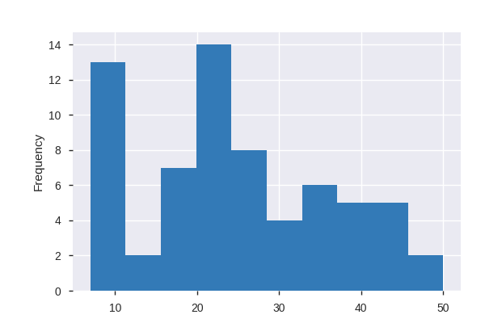

**Common Values**

| Value | Count | Frequency (%) |  |
| --- | --- | --- | --- |
| 22 | 6 | 9.1% |  |
| 8 | 4 | 6.1% |  |
| 26 | 3 | 4.5% |  |
| 9 | 3 | 4.5% |  |
| 11 | 3 | 4.5% |  |
| 19 | 3 | 4.5% |  |
| 21 | 3 | 4.5% |  |
| 27 | 3 | 4.5% |  |
| 30 | 2 | 3.0% |  |
| 18 | 2 | 3.0% |  |
| Other values (26) | 34 | 51.5% |  |

**Extreme Values**

Minimum 5 values

| Value | Count | Frequency (%) |  |
| --- | --- | --- | --- |
| 7 | 2 | 3.0% |  |
| 8 | 4 | 6.1% |  |
| 9 | 3 | 4.5% |  |
| 10 | 1 | 1.5% |  |
| 11 | 3 | 4.5% |  |

Maximum 5 values

| Value | Count | Frequency (%) |  |
| --- | --- | --- | --- |
| 43 | 1 | 1.5% |  |
| 44 | 1 | 1.5% |  |
| 45 | 1 | 1.5% |  |
| 48 | 1 | 1.5% |  |
| 50 | 1 | 1.5% |  |

Age group  
Categorical

| Distinct count | 3 |
| --- | --- |
| Unique (%) | 4.5% |
| Missing (%) | 0.0% |
| Missing (n) | 0 |

| 25-50 | 30 |
| --- | --- |
| 13-24 | 22 |
| <13 | 14 |

Toggle details

| Value | Count | Frequency (%) |  |
| --- | --- | --- | --- |
| 25-50 | 30 | 45.5% |  |
| 13-24 | 22 | 33.3% |  |
| <13 | 14 | 21.2% |  |

Gender  
Categorical

| Distinct count | 2 |
| --- | --- |
| Unique (%) | 3.0% |
| Missing (%) | 0.0% |
| Missing (n) | 0 |

| Female | 42 |
| --- | --- |
| Male | 24 |

Toggle details

| Value | Count | Frequency (%) |  |
| --- | --- | --- | --- |
| Female | 42 | 63.6% |  |
| Male | 24 | 36.4% |  |

Height  
Numeric

| Distinct count | 38 |
| --- | --- |
| Unique (%) | 57.6% |
| Missing (%) | 12.1% |
| Missing (n) | 8 |
| Infinite (%) | 0.0% |
| Infinite (n) | 0 |

| Mean | 160.74 |
| --- | --- |
| Minimum | 116 |
| Maximum | 190 |
| Zeros (%) | 0.0% |

Toggle details

**Statistics**

Quantile statistics

| Minimum | 116 |
| --- | --- |
| 5-th percentile | 126 |
| Q1 | 152.25 |
| Median | 164 |
| Q3 | 171 |
| 95-th percentile | 184.15 |
| Maximum | 190 |
| Range | 74 |
| Interquartile range | 18.75 |

Descriptive statistics

| Standard deviation | 17.21 |
| --- | --- |
| Coef of variation | 0.10707 |
| Kurtosis | 0.18292 |
| Mean | 160.74 |
| MAD | 13.252 |
| Skewness | -0.82623 |
| Sum | 9323 |
| Variance | 296.2 |
| Memory size | 656.0 B |

**Histogram**

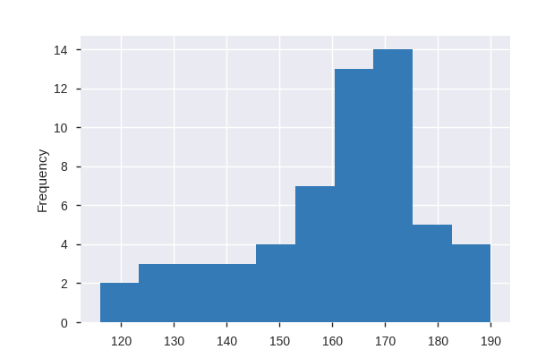

**Common Values**

| Value | Count | Frequency (%) |  |
| --- | --- | --- | --- |
| 164.0 | 4 | 6.1% |  |
| 169.0 | 4 | 6.1% |  |
| 165.0 | 3 | 4.5% |  |
| 158.0 | 3 | 4.5% |  |
| 152.0 | 2 | 3.0% |  |
| 180.0 | 2 | 3.0% |  |
| 170.0 | 2 | 3.0% |  |
| 171.0 | 2 | 3.0% |  |
| 163.0 | 2 | 3.0% |  |
| 185.0 | 2 | 3.0% |  |
| Other values (27) | 32 | 48.5% |  |
| (Missing) | 8 | 12.1% |  |

**Extreme Values**

Minimum 5 values

| Value | Count | Frequency (%) |  |
| --- | --- | --- | --- |
| 116.0 | 1 | 1.5% |  |
| 122.0 | 1 | 1.5% |  |
| 126.0 | 2 | 3.0% |  |
| 127.0 | 1 | 1.5% |  |
| 131.0 | 1 | 1.5% |  |

Maximum 5 values

| Value | Count | Frequency (%) |  |
| --- | --- | --- | --- |
| 181.0 | 1 | 1.5% |  |
| 182.0 | 1 | 1.5% |  |
| 184.0 | 1 | 1.5% |  |
| 185.0 | 2 | 3.0% |  |
| 190.0 | 1 | 1.5% |  |

Weight  
Numeric

| Distinct count | 41 |
| --- | --- |
| Unique (%) | 62.1% |
| Missing (%) | 7.6% |
| Missing (n) | 5 |
| Infinite (%) | 0.0% |
| Infinite (n) | 0 |

| Mean | 56.098 |
| --- | --- |
| Minimum | 21 |
| Maximum | 86 |
| Zeros (%) | 0.0% |

Toggle details

**Statistics**

Quantile statistics

| Minimum | 21 |
| --- | --- |
| 5-th percentile | 30 |
| Q1 | 48 |
| Median | 56 |
| Q3 | 66 |
| 95-th percentile | 84 |
| Maximum | 86 |
| Range | 65 |
| Interquartile range | 18 |

Descriptive statistics

| Standard deviation | 16.764 |
| --- | --- |
| Coef of variation | 0.29883 |
| Kurtosis | -0.57645 |
| Mean | 56.098 |
| MAD | 13.149 |
| Skewness | -0.11505 |
| Sum | 3422 |
| Variance | 281.02 |
| Memory size | 656.0 B |

**Histogram**

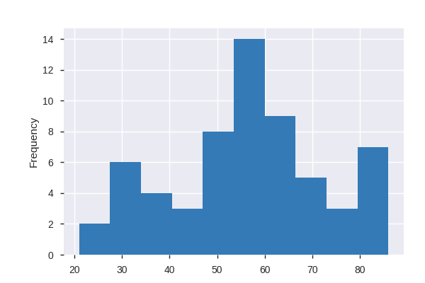

**Common Values**

| Value | Count | Frequency (%) |  |
| --- | --- | --- | --- |
| 55.0 | 5 | 7.6% |  |
| 65.0 | 3 | 4.5% |  |
| 48.0 | 3 | 4.5% |  |
| 58.0 | 3 | 4.5% |  |
| 75.0 | 2 | 3.0% |  |
| 72.0 | 2 | 3.0% |  |
| 57.0 | 2 | 3.0% |  |
| 56.0 | 2 | 3.0% |  |
| 66.0 | 2 | 3.0% |  |
| 42.0 | 2 | 3.0% |  |
| Other values (30) | 35 | 53.0% |  |
| (Missing) | 5 | 7.6% |  |

**Extreme Values**

Minimum 5 values

| Value | Count | Frequency (%) |  |
| --- | --- | --- | --- |
| 21.0 | 2 | 3.0% |  |
| 29.0 | 1 | 1.5% |  |
| 30.0 | 1 | 1.5% |  |
| 31.0 | 1 | 1.5% |  |
| 32.0 | 2 | 3.0% |  |

Maximum 5 values

| Value | Count | Frequency (%) |  |
| --- | --- | --- | --- |
| 81.0 | 1 | 1.5% |  |
| 83.0 | 1 | 1.5% |  |
| 84.0 | 1 | 1.5% |  |
| 85.0 | 1 | 1.5% |  |
| 86.0 | 2 | 3.0% |  |

BMI  
Categorical

| Distinct count | 56 |
| --- | --- |
| Unique (%) | 84.8% |
| Missing (%) | 13.6% |
| Missing (n) | 9 |

| -2.138.512.805 | 2 |
| --- | --- |
| -2.019.136.618 | 2 |
| 1.822.222.222 | 1 |
| Other values (52) | 52 |
| (Missing) | 9 |

Toggle details

| Value | Count | Frequency (%) |  |
| --- | --- | --- | --- |
| -2.138.512.805 | 2 | 3.0% |  |
| -2.019.136.618 | 2 | 3.0% |  |
| 1.822.222.222 | 1 | 1.5% |  |
| 1.385.041.551 | 1 | 1.5% |  |
| 1.560.642.093 | 1 | 1.5% |  |
| -1.700.418.900 | 1 | 1.5% |  |
| 21.484.375 | 1 | 1.5% |  |
| -2.106.259.659 | 1 | 1.5% |  |
| 216.066.482 | 1 | 1.5% |  |
| -1.650.069.337 | 1 | 1.5% |  |
| Other values (45) | 45 | 68.2% |  |
| (Missing) | 9 | 13.6% |  |

BMI group  
Categorical

| Distinct count | 5 |
| --- | --- |
| Unique (%) | 7.6% |
| Missing (%) | 13.6% |
| Missing (n) | 9 |

| Normal weight | 41 |
| --- | --- |
| Underweight | 10 |
| Overweight | 5 |
| (Missing) | 9 |

Toggle details

| Value | Count | Frequency (%) |  |
| --- | --- | --- | --- |
| Normal weight | 41 | 62.1% |  |
| Underweight | 10 | 15.2% |  |
| Overweight | 5 | 7.6% |  |
| Obese | 1 | 1.5% |  |
| (Missing) | 9 | 13.6% |  |

Smoke habits  
Categorical

| Distinct count | 3 |
| --- | --- |
| Unique (%) | 4.5% |
| Missing (%) | 0.0% |
| Missing (n) | 0 |

| No | 57 |
| --- | --- |
| Ex-fumador | 8 |
| Yes | 1 |

Toggle details

| Value | Count | Frequency (%) |  |
| --- | --- | --- | --- |
| No | 57 | 86.4% |  |
| Ex-fumador | 8 | 12.1% |  |
| Yes | 1 | 1.5% |  |

Alcool habits  
Categorical

| Distinct count | 2 |
| --- | --- |
| Unique (%) | 3.0% |
| Missing (%) | 0.0% |
| Missing (n) | 0 |

| No | 35 |
| --- | --- |
| Yes | 31 |

Toggle details

| Value | Count | Frequency (%) |  |
| --- | --- | --- | --- |
| No | 35 | 53.0% |  |
| Yes | 31 | 47.0% |  |

Menopause  
Categorical

| Distinct count | 2 |
| --- | --- |
| Unique (%) | 3.0% |
| Missing (%) | 0.0% |
| Missing (n) | 0 |

| No | 42 |
| --- | --- |
| Man | 24 |

Toggle details

| Value | Count | Frequency (%) |  |
| --- | --- | --- | --- |
| No | 42 | 63.6% |  |
| Man | 24 | 36.4% |  |

Anticonceptionals  
Categorical

| Distinct count | 3 |
| --- | --- |
| Unique (%) | 4.5% |
| Missing (%) | 39.4% |
| Missing (n) | 26 |

| Man | 24 |
| --- | --- |
| Yes | 16 |
| (Missing) | 26 |

Toggle details

| Value | Count | Frequency (%) |  |
| --- | --- | --- | --- |
| Man | 24 | 36.4% |  |
| Yes | 16 | 24.2% |  |
| (Missing) | 26 | 39.4% |  |

Blood type  
Categorical

| Distinct count | 5 |
| --- | --- |
| Unique (%) | 7.6% |
| Missing (%) | 50.0% |
| Missing (n) | 33 |

| A | 17 |
| --- | --- |
| O | 12 |
| AB | 2 |
| (Missing) | 33 |

Toggle details

| Value | Count | Frequency (%) |  |
| --- | --- | --- | --- |
| A | 17 | 25.8% |  |
| O | 12 | 18.2% |  |
| AB | 2 | 3.0% |  |
| B | 2 | 3.0% |  |
| (Missing) | 33 | 50.0% |  |

RH type  
Categorical

| Distinct count | 3 |
| --- | --- |
| Unique (%) | 4.5% |
| Missing (%) | 59.1% |
| Missing (n) | 39 |

| + | 24 |
| --- | --- |
| - | 3 |
| (Missing) | 39 |

Toggle details

| Value | Count | Frequency (%) |  |
| --- | --- | --- | --- |
| + | 24 | 36.4% |  |
| - | 3 | 4.5% |  |
| (Missing) | 39 | 59.1% |  |

Hipertension  
Categorical

| Distinct count | 2 |
| --- | --- |
| Unique (%) | 3.0% |
| Missing (%) | 0.0% |
| Missing (n) | 0 |

| No | 65 |
| --- | --- |
| Yes | 1 |

Toggle details

| Value | Count | Frequency (%) |  |
| --- | --- | --- | --- |
| No | 65 | 98.5% |  |
| Yes | 1 | 1.5% |  |

Diabetes  
Categorical

| Distinct count | 2 |
| --- | --- |
| Unique (%) | 3.0% |
| Missing (%) | 0.0% |
| Missing (n) | 0 |

| No | 65 |
| --- | --- |
| Nosabe (se tem) | 1 |

Toggle details

| Value | Count | Frequency (%) |  |
| --- | --- | --- | --- |
| No | 65 | 98.5% |  |
| Nosabe (se tem) | 1 | 1.5% |  |

Cardiac  
Categorical

| Distinct count | 2 |
| --- | --- |
| Unique (%) | 3.0% |
| Missing (%) | 1.5% |
| Missing (n) | 1 |

| No | 65 |
| --- | --- |
| (Missing) | 1 |

Toggle details

| Value | Count | Frequency (%) |  |
| --- | --- | --- | --- |
| No | 65 | 98.5% |  |
| (Missing) | 1 | 1.5% |  |

Blood  
Categorical

| Distinct count | 2 |
| --- | --- |
| Unique (%) | 3.0% |
| Missing (%) | 7.6% |
| Missing (n) | 5 |

| No | 61 |
| --- | --- |
| (Missing) | 5 |

Toggle details

| Value | Count | Frequency (%) |  |
| --- | --- | --- | --- |
| No | 61 | 92.4% |  |
| (Missing) | 5 | 7.6% |  |

Liver  
Categorical

| Distinct count | 2 |
| --- | --- |
| Unique (%) | 3.0% |
| Missing (%) | 33.3% |
| Missing (n) | 22 |

| No | 44 |
| --- | --- |
| (Missing) | 22 |

Toggle details

| Value | Count | Frequency (%) |  |
| --- | --- | --- | --- |
| No | 44 | 66.7% |  |
| (Missing) | 22 | 33.3% |  |

Stomach  
Categorical

| Distinct count | 3 |
| --- | --- |
| Unique (%) | 4.5% |
| Missing (%) | 4.5% |
| Missing (n) | 3 |

| No | 62 |
| --- | --- |
| Gastrite | 1 |
| (Missing) | 3 |

Toggle details

| Value | Count | Frequency (%) |  |
| --- | --- | --- | --- |
| No | 62 | 93.9% |  |
| Gastrite | 1 | 1.5% |  |
| (Missing) | 3 | 4.5% |  |

Kidney  
Categorical

| Distinct count | 2 |
| --- | --- |
| Unique (%) | 3.0% |
| Missing (%) | 3.0% |
| Missing (n) | 2 |

| No | 64 |
| --- | --- |
| (Missing) | 2 |

Toggle details

| Value | Count | Frequency (%) |  |
| --- | --- | --- | --- |
| No | 64 | 97.0% |  |
| (Missing) | 2 | 3.0% |  |

Other diseases  
Categorical

| Distinct count | 5 |
| --- | --- |
| Unique (%) | 7.6% |
| Missing (%) | 27.3% |
| Missing (n) | 18 |

| No | 40 |
| --- | --- |
| Sinusite | 6 |
| Asma Sinusite | 1 |
| (Missing) | 18 |

Toggle details

| Value | Count | Frequency (%) |  |
| --- | --- | --- | --- |
| No | 40 | 60.6% |  |
| Sinusite | 6 | 9.1% |  |
| Asma Sinusite | 1 | 1.5% |  |
| Urtic聽ria Sinusite | 1 | 1.5% |  |
| (Missing) | 18 | 27.3% |  |

Allergy  
Categorical

| Distinct count | 2 |
| --- | --- |
| Unique (%) | 3.0% |
| Missing (%) | 0.0% |
| Missing (n) | 0 |

| No | 53 |
| --- | --- |
| Yes | 13 |

Toggle details

| Value | Count | Frequency (%) |  |
| --- | --- | --- | --- |
| No | 53 | 80.3% |  |
| Yes | 13 | 19.7% |  |

Radio or Cheical Therapy  
Constant

*This variable is constant and should be ignored for analysis*

| Constant value | No |
| --- | --- |

Health problems score  
Numeric

| Distinct count | 7 |
| --- | --- |
| Unique (%) | 10.6% |
| Missing (%) | 0.0% |
| Missing (n) | 0 |
| Infinite (%) | 0.0% |
| Infinite (n) | 0 |

| Mean | 0.54545 |
| --- | --- |
| Minimum | 0 |
| Maximum | 6 |
| Zeros (%) | 72.7% |

Toggle details

**Statistics**

Quantile statistics

| Minimum | 0 |
| --- | --- |
| 5-th percentile | 0 |
| Q1 | 0 |
| Median | 0 |
| Q3 | 1 |
| 95-th percentile | 2.75 |
| Maximum | 6 |
| Range | 6 |
| Interquartile range | 1 |

Descriptive statistics

| Standard deviation | 1.192 |
| --- | --- |
| Coef of variation | 2.1854 |
| Kurtosis | 9.2255 |
| Mean | 0.54545 |
| MAD | 0.79339 |
| Skewness | 2.9237 |
| Sum | 36 |
| Variance | 1.421 |
| Memory size | 656.0 B |

**Histogram**

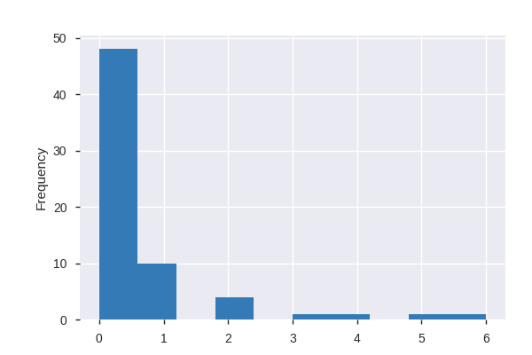

**Common Values**

| Value | Count | Frequency (%) |  |
| --- | --- | --- | --- |
| 0 | 48 | 72.7% |  |
| 1 | 10 | 15.2% |  |
| 2 | 4 | 6.1% |  |
| 6 | 1 | 1.5% |  |
| 5 | 1 | 1.5% |  |
| 4 | 1 | 1.5% |  |
| 3 | 1 | 1.5% |  |

**Extreme Values**

Minimum 5 values

| Value | Count | Frequency (%) |  |
| --- | --- | --- | --- |
| 0 | 48 | 72.7% |  |
| 1 | 10 | 15.2% |  |
| 2 | 4 | 6.1% |  |
| 3 | 1 | 1.5% |  |
| 4 | 1 | 1.5% |  |

Maximum 5 values

| Value | Count | Frequency (%) |  |
| --- | --- | --- | --- |
| 2 | 4 | 6.1% |  |
| 3 | 1 | 1.5% |  |
| 4 | 1 | 1.5% |  |
| 5 | 1 | 1.5% |  |
| 6 | 1 | 1.5% |  |

Regular medication  
Categorical

| Distinct count | 2 |
| --- | --- |
| Unique (%) | 3.0% |
| Missing (%) | 0.0% |
| Missing (n) | 0 |

| No | 65 |
| --- | --- |
| Yes | 1 |

Toggle details

| Value | Count | Frequency (%) |  |
| --- | --- | --- | --- |
| No | 65 | 98.5% |  |
| Yes | 1 | 1.5% |  |

Medication  
Categorical

| Distinct count | 2 |
| --- | --- |
| Unique (%) | 3.0% |
| Missing (%) | 98.5% |
| Missing (n) | 65 |

| rotina | 1 |
| --- | --- |
| (Missing) | 65 |

Toggle details

| Value | Count | Frequency (%) |  |
| --- | --- | --- | --- |
| rotina | 1 | 1.5% |  |
| (Missing) | 65 | 98.5% |  |

Treatment last 30 days  
Categorical

| Distinct count | 4 |
| --- | --- |
| Unique (%) | 6.1% |
| Missing (%) | 95.5% |
| Missing (n) | 63 |

| aines | 1 |
| --- | --- |
| ibuprofeno 660mg | 1 |
| AINE | 1 |
| (Missing) | 63 |

Toggle details

| Value | Count | Frequency (%) |  |
| --- | --- | --- | --- |
| aines | 1 | 1.5% |  |
| ibuprofeno 660mg | 1 | 1.5% |  |
| AINE | 1 | 1.5% |  |
| (Missing) | 63 | 95.5% |  |

Antibiotic  
Categorical

| Distinct count | 2 |
| --- | --- |
| Unique (%) | 3.0% |
| Missing (%) | 98.5% |
| Missing (n) | 65 |

| clavamoxDT | 1 |
| --- | --- |
| (Missing) | 65 |

Toggle details

| Value | Count | Frequency (%) |  |
| --- | --- | --- | --- |
| clavamoxDT | 1 | 1.5% |  |
| (Missing) | 65 | 98.5% |  |

Diet type  
Categorical

| Distinct count | 3 |
| --- | --- |
| Unique (%) | 4.5% |
| Missing (%) | 30.3% |
| Missing (n) | 20 |

| Other | 33 |
| --- | --- |
| Mediterranean | 13 |
| (Missing) | 20 |

Toggle details

| Value | Count | Frequency (%) |  |
| --- | --- | --- | --- |
| Other | 33 | 50.0% |  |
| Mediterranean | 13 | 19.7% |  |
| (Missing) | 20 | 30.3% |  |

PSR 1st  
Constant

*This variable is constant and should be ignored for analysis*

| Constant value |  |
| --- | --- |

PSR 2nd  
Constant

*This variable is constant and should be ignored for analysis*

| Constant value |  |
| --- | --- |

PSR 3th  
Constant

*This variable is constant and should be ignored for analysis*

| Constant value |  |
| --- | --- |

PSR 4th  
Constant

*This variable is constant and should be ignored for analysis*

| Constant value |  |
| --- | --- |

PSR 5th  
Constant

*This variable is constant and should be ignored for analysis*

| Constant value |  |
| --- | --- |

PSR 6th  
Constant

*This variable is constant and should be ignored for analysis*

| Constant value |  |
| --- | --- |

C  
Numeric

| Distinct count | 8 |
| --- | --- |
| Unique (%) | 12.1% |
| Missing (%) | 24.2% |
| Missing (n) | 16 |
| Infinite (%) | 0.0% |
| Infinite (n) | 0 |

| Mean | 0.64 |
| --- | --- |
| Minimum | 0 |
| Maximum | 6 |
| Zeros (%) | 60.6% |

Toggle details

**Statistics**

Quantile statistics

| Minimum | 0 |
| --- | --- |
| 5-th percentile | 0 |
| Q1 | 0 |
| Median | 0 |
| Q3 | 0 |
| 95-th percentile | 4.55 |
| Maximum | 6 |
| Range | 6 |
| Interquartile range | 0 |

Descriptive statistics

| Standard deviation | 1.495 |
| --- | --- |
| Coef of variation | 2.336 |
| Kurtosis | 4.8934 |
| Mean | 0.64 |
| MAD | 1.024 |
| Skewness | 2.4087 |
| Sum | 32 |
| Variance | 2.2351 |
| Memory size | 656.0 B |

**Histogram**

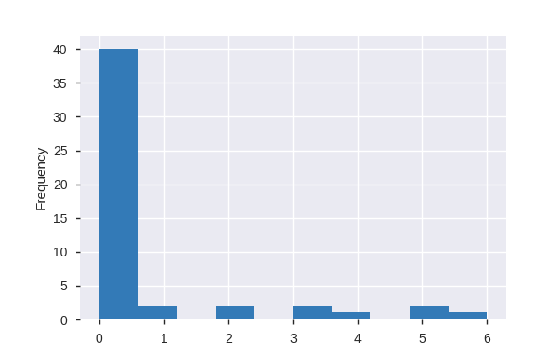

**Common Values**

| Value | Count | Frequency (%) |  |
| --- | --- | --- | --- |
| 0.0 | 40 | 60.6% |  |
| 5.0 | 2 | 3.0% |  |
| 3.0 | 2 | 3.0% |  |
| 1.0 | 2 | 3.0% |  |
| 2.0 | 2 | 3.0% |  |
| 6.0 | 1 | 1.5% |  |
| 4.0 | 1 | 1.5% |  |
| (Missing) | 16 | 24.2% |  |

**Extreme Values**

Minimum 5 values

| Value | Count | Frequency (%) |  |
| --- | --- | --- | --- |
| 0.0 | 40 | 60.6% |  |
| 1.0 | 2 | 3.0% |  |
| 2.0 | 2 | 3.0% |  |
| 3.0 | 2 | 3.0% |  |
| 4.0 | 1 | 1.5% |  |

Maximum 5 values

| Value | Count | Frequency (%) |  |
| --- | --- | --- | --- |
| 2.0 | 2 | 3.0% |  |
| 3.0 | 2 | 3.0% |  |
| 4.0 | 1 | 1.5% |  |
| 5.0 | 2 | 3.0% |  |
| 6.0 | 1 | 1.5% |  |

P  
Numeric

| Distinct count | 7 |
| --- | --- |
| Unique (%) | 10.6% |
| Missing (%) | 33.3% |
| Missing (n) | 22 |
| Infinite (%) | 0.0% |
| Infinite (n) | 0 |

| Mean | 0.47727 |
| --- | --- |
| Minimum | 0 |
| Maximum | 9 |
| Zeros (%) | 56.1% |

Toggle details

**Statistics**

Quantile statistics

| Minimum | 0 |
| --- | --- |
| 5-th percentile | 0 |
| Q1 | 0 |
| Median | 0 |
| Q3 | 0 |
| 95-th percentile | 2.85 |
| Maximum | 9 |
| Range | 9 |
| Interquartile range | 0 |

Descriptive statistics

| Standard deviation | 1.5475 |
| --- | --- |
| Coef of variation | 3.2424 |
| Kurtosis | 22.32 |
| Mean | 0.47727 |
| MAD | 0.80269 |
| Skewness | 4.4622 |
| Sum | 21 |
| Variance | 2.3948 |
| Memory size | 656.0 B |

**Histogram**

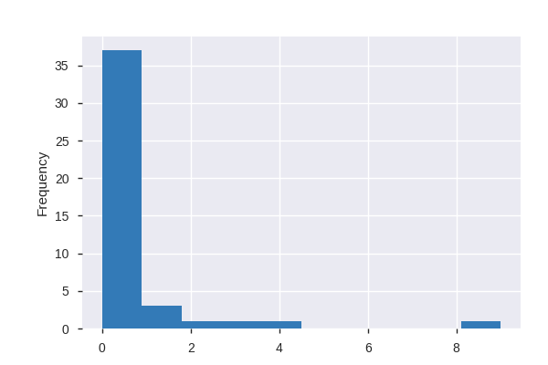

**Common Values**

| Value | Count | Frequency (%) |  |
| --- | --- | --- | --- |
| 0.0 | 37 | 56.1% |  |
| 1.0 | 3 | 4.5% |  |
| 9.0 | 1 | 1.5% |  |
| 3.0 | 1 | 1.5% |  |
| 4.0 | 1 | 1.5% |  |
| 2.0 | 1 | 1.5% |  |
| (Missing) | 22 | 33.3% |  |

**Extreme Values**

Minimum 5 values

| Value | Count | Frequency (%) |  |
| --- | --- | --- | --- |
| 0.0 | 37 | 56.1% |  |
| 1.0 | 3 | 4.5% |  |
| 2.0 | 1 | 1.5% |  |
| 3.0 | 1 | 1.5% |  |
| 4.0 | 1 | 1.5% |  |

Maximum 5 values

| Value | Count | Frequency (%) |  |
| --- | --- | --- | --- |
| 1.0 | 3 | 4.5% |  |
| 2.0 | 1 | 1.5% |  |
| 3.0 | 1 | 1.5% |  |
| 4.0 | 1 | 1.5% |  |
| 9.0 | 1 | 1.5% |  |

O  
Numeric

| Distinct count | 10 |
| --- | --- |
| Unique (%) | 15.2% |
| Missing (%) | 12.1% |
| Missing (n) | 8 |
| Infinite (%) | 0.0% |
| Infinite (n) | 0 |

| Mean | 2.5862 |
| --- | --- |
| Minimum | 0 |
| Maximum | 9 |
| Zeros (%) | 30.3% |

Toggle details

**Statistics**

Quantile statistics

| Minimum | 0 |
| --- | --- |
| 5-th percentile | 0 |
| Q1 | 0 |
| Median | 2 |
| Q3 | 4.75 |
| 95-th percentile | 8 |
| Maximum | 9 |
| Range | 9 |
| Interquartile range | 4.75 |

Descriptive statistics

| Standard deviation | 2.7723 |
| --- | --- |
| Coef of variation | 1.0719 |
| Kurtosis | -0.47047 |
| Mean | 2.5862 |
| MAD | 2.3484 |
| Skewness | 0.85106 |
| Sum | 150 |
| Variance | 7.6854 |
| Memory size | 656.0 B |

**Histogram**

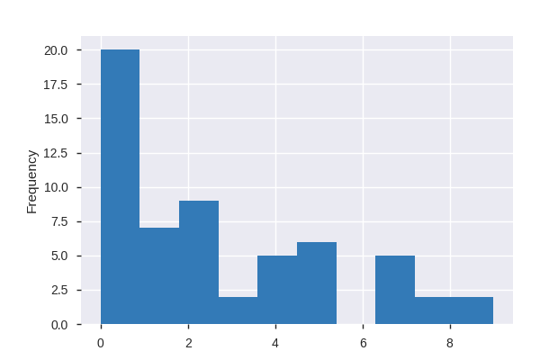

**Common Values**

| Value | Count | Frequency (%) |  |
| --- | --- | --- | --- |
| 0.0 | 20 | 30.3% |  |
| 2.0 | 9 | 13.6% |  |
| 1.0 | 7 | 10.6% |  |
| 5.0 | 6 | 9.1% |  |
| 4.0 | 5 | 7.6% |  |
| 7.0 | 5 | 7.6% |  |
| 9.0 | 2 | 3.0% |  |
| 8.0 | 2 | 3.0% |  |
| 3.0 | 2 | 3.0% |  |
| (Missing) | 8 | 12.1% |  |

**Extreme Values**

Minimum 5 values

| Value | Count | Frequency (%) |  |
| --- | --- | --- | --- |
| 0.0 | 20 | 30.3% |  |
| 1.0 | 7 | 10.6% |  |
| 2.0 | 9 | 13.6% |  |
| 3.0 | 2 | 3.0% |  |
| 4.0 | 5 | 7.6% |  |

Maximum 5 values

| Value | Count | Frequency (%) |  |
| --- | --- | --- | --- |
| 4.0 | 5 | 7.6% |  |
| 5.0 | 6 | 9.1% |  |
| 7.0 | 5 | 7.6% |  |
| 8.0 | 2 | 3.0% |  |
| 9.0 | 2 | 3.0% |  |

CPOD  
Highly correlated

*This variable is highly correlated with `O` and should be ignored for analysis*

| Correlation | 0.92866 |
| --- | --- |

Oral diagnostic  
Categorical

| Distinct count | 4 |
| --- | --- |
| Unique (%) | 6.1% |
| Missing (%) | 0.0% |
| Missing (n) | 0 |

| Health | 58 |
| --- | --- |
| Other | 4 |
| Gingivitis | 2 |

Toggle details

| Value | Count | Frequency (%) |  |
| --- | --- | --- | --- |
| Health | 58 | 87.9% |  |
| Other | 4 | 6.1% |  |
| Gingivitis | 2 | 3.0% |  |
| Periodontitis | 2 | 3.0% |  |

MMP9  
Numeric

| Distinct count | 9 |
| --- | --- |
| Unique (%) | 13.6% |
| Missing (%) | 87.9% |
| Missing (n) | 58 |
| Infinite (%) | 0.0% |
| Infinite (n) | 0 |

| Mean | 8.025 |
| --- | --- |
| Minimum | 0.05 |
| Maximum | 36.85 |
| Zeros (%) | 0.0% |

Toggle details

**Statistics**

Quantile statistics

| Minimum | 0.05 |
| --- | --- |
| 5-th percentile | 0.1165 |
| Q1 | 0.4725 |
| Median | 0.98 |
| Q3 | 8.7175 |
| 95-th percentile | 30.739 |
| Maximum | 36.85 |
| Range | 36.8 |
| Interquartile range | 8.245 |

Descriptive statistics

| Standard deviation | 13.351 |
| --- | --- |
| Coef of variation | 1.6637 |
| Kurtosis | 2.9013 |
| Mean | 8.025 |
| MAD | 10.047 |
| Skewness | 1.8647 |
| Sum | 64.2 |
| Variance | 178.24 |
| Memory size | 656.0 B |

**Histogram**

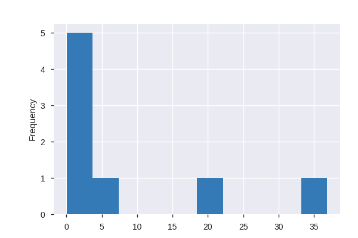

**Common Values**

| Value | Count | Frequency (%) |  |
| --- | --- | --- | --- |
| 0.55 | 1 | 1.5% |  |
| 0.05 | 1 | 1.5% |  |
| 19.39 | 1 | 1.5% |  |
| 36.85 | 1 | 1.5% |  |
| 0.74 | 1 | 1.5% |  |
| 5.16 | 1 | 1.5% |  |
| 0.24 | 1 | 1.5% |  |
| 1.22 | 1 | 1.5% |  |
| (Missing) | 58 | 87.9% |  |

**Extreme Values**

Minimum 5 values

| Value | Count | Frequency (%) |  |
| --- | --- | --- | --- |
| 0.05 | 1 | 1.5% |  |
| 0.24 | 1 | 1.5% |  |
| 0.55 | 1 | 1.5% |  |
| 0.74 | 1 | 1.5% |  |
| 1.22 | 1 | 1.5% |  |

Maximum 5 values

| Value | Count | Frequency (%) |  |
| --- | --- | --- | --- |
| 0.74 | 1 | 1.5% |  |
| 1.22 | 1 | 1.5% |  |
| 5.16 | 1 | 1.5% |  |
| 19.39 | 1 | 1.5% |  |
| 36.85 | 1 | 1.5% |  |

B-Endorphin  
Constant

*This variable is constant and should be ignored for analysis*

| Constant value |  |
| --- | --- |

Orexin A  
Boolean

| Distinct count | 2 |
| --- | --- |
| Unique (%) | 3.0% |
| Missing (%) | 98.5% |
| Missing (n) | 65 |

| Mean | 9.55 |
| --- | --- |

| 9.55 | 1 |
| --- | --- |
| (Missing) | 65 |

Toggle details

| Value | Count | Frequency (%) |  |
| --- | --- | --- | --- |
| 9.55 | 1 | 1.5% |  |
| (Missing) | 65 | 98.5% |  |

Oxytocin  
Constant

*This variable is constant and should be ignored for analysis*

| Constant value |  |
| --- | --- |

Substance P  
Boolean

| Distinct count | 2 |
| --- | --- |
| Unique (%) | 3.0% |
| Missing (%) | 98.5% |
| Missing (n) | 65 |

| Mean | 0.01 |
| --- | --- |

| 0.01 | 1 |
| --- | --- |
| (Missing) | 65 |

Toggle details

| Value | Count | Frequency (%) |  |
| --- | --- | --- | --- |
| 0.01 | 1 | 1.5% |  |
| (Missing) | 65 | 98.5% |  |

CCL3  
Numeric

| Distinct count | 5 |
| --- | --- |
| Unique (%) | 7.6% |
| Missing (%) | 93.9% |
| Missing (n) | 62 |
| Infinite (%) | 0.0% |
| Infinite (n) | 0 |

| Mean | 127.89 |
| --- | --- |
| Minimum | 14.22 |
| Maximum | 404.27 |
| Zeros (%) | 0.0% |

Toggle details

**Statistics**

Quantile statistics

| Minimum | 14.22 |
| --- | --- |
| 5-th percentile | 15.905 |
| Q1 | 22.642 |
| Median | 46.54 |
| Q3 | 151.79 |
| 95-th percentile | 353.77 |
| Maximum | 404.27 |
| Range | 390.05 |
| Interquartile range | 129.15 |

Descriptive statistics

| Standard deviation | 185.68 |
| --- | --- |
| Coef of variation | 1.4518 |
| Kurtosis | 3.6755 |
| Mean | 127.89 |
| MAD | 138.19 |
| Skewness | 1.9107 |
| Sum | 511.57 |
| Variance | 34477 |
| Memory size | 656.0 B |

**Histogram**

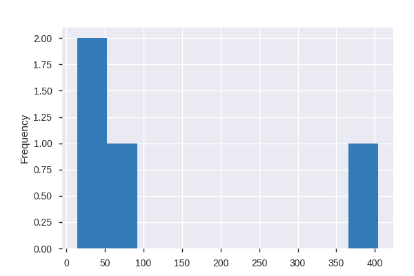

**Common Values**

| Value | Count | Frequency (%) |  |
| --- | --- | --- | --- |
| 25.45 | 1 | 1.5% |  |
| 404.27 | 1 | 1.5% |  |
| 14.22 | 1 | 1.5% |  |
| 67.63 | 1 | 1.5% |  |
| (Missing) | 62 | 93.9% |  |

**Extreme Values**

Minimum 5 values

| Value | Count | Frequency (%) |  |
| --- | --- | --- | --- |
| 14.22 | 1 | 1.5% |  |
| 25.45 | 1 | 1.5% |  |
| 67.63 | 1 | 1.5% |  |
| 404.27 | 1 | 1.5% |  |

Maximum 5 values

| Value | Count | Frequency (%) |  |
| --- | --- | --- | --- |
| 14.22 | 1 | 1.5% |  |
| 25.45 | 1 | 1.5% |  |
| 67.63 | 1 | 1.5% |  |
| 404.27 | 1 | 1.5% |  |

CCL13  
Highly correlated

*This variable is highly correlated with `CCL3` and should be ignored for analysis*

| Correlation | 0.99981 |
| --- | --- |

IL1b  
Numeric

| Distinct count | 4 |
| --- | --- |
| Unique (%) | 6.1% |
| Missing (%) | 95.5% |
| Missing (n) | 63 |
| Infinite (%) | 0.0% |
| Infinite (n) | 0 |

| Mean | 7.1167 |
| --- | --- |
| Minimum | 2.27 |
| Maximum | 14.4 |
| Zeros (%) | 0.0% |

Toggle details

**Statistics**

Quantile statistics

| Minimum | 2.27 |
| --- | --- |
| 5-th percentile | 2.511 |
| Q1 | 3.475 |
| Median | 4.68 |
| Q3 | 9.54 |
| 95-th percentile | 13.428 |
| Maximum | 14.4 |
| Range | 12.13 |
| Interquartile range | 6.065 |

Descriptive statistics

| Standard deviation | 6.4216 |
| --- | --- |
| Coef of variation | 0.90234 |
| Kurtosis |  |
| Mean | 7.1167 |
| MAD | 4.8556 |
| Skewness | 1.4617 |
| Sum | 21.35 |
| Variance | 41.237 |
| Memory size | 656.0 B |

**Histogram**

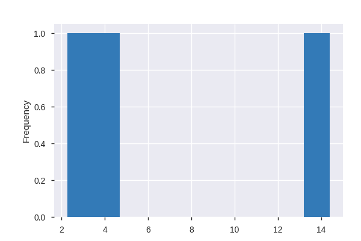

**Common Values**

| Value | Count | Frequency (%) |  |
| --- | --- | --- | --- |
| 2.27 | 1 | 1.5% |  |
| 14.4 | 1 | 1.5% |  |
| 4.68 | 1 | 1.5% |  |
| (Missing) | 63 | 95.5% |  |

**Extreme Values**

Minimum 5 values

| Value | Count | Frequency (%) |  |
| --- | --- | --- | --- |
| 2.27 | 1 | 1.5% |  |
| 4.68 | 1 | 1.5% |  |
| 14.4 | 1 | 1.5% |  |

Maximum 5 values

| Value | Count | Frequency (%) |  |
| --- | --- | --- | --- |
| 2.27 | 1 | 1.5% |  |
| 4.68 | 1 | 1.5% |  |
| 14.4 | 1 | 1.5% |  |

IL-4  
Constant

*This variable is constant and should be ignored for analysis*

| Constant value |  |
| --- | --- |

IL-6  
Constant

*This variable is constant and should be ignored for analysis*

| Constant value |  |
| --- | --- |

IL10  
Boolean

| Distinct count | 2 |
| --- | --- |
| Unique (%) | 3.0% |
| Missing (%) | 98.5% |
| Missing (n) | 65 |

| Mean | 17.59 |
| --- | --- |

| 17.59 | 1 |
| --- | --- |
| (Missing) | 65 |

Toggle details

| Value | Count | Frequency (%) |  |
| --- | --- | --- | --- |
| 17.59 | 1 | 1.5% |  |
| (Missing) | 65 | 98.5% |  |

IL17A  
Boolean

| Distinct count | 2 |
| --- | --- |
| Unique (%) | 3.0% |
| Missing (%) | 98.5% |
| Missing (n) | 65 |

| Mean | 3.57 |
| --- | --- |

| 3.57 | 1 |
| --- | --- |
| (Missing) | 65 |

Toggle details

| Value | Count | Frequency (%) |  |
| --- | --- | --- | --- |
| 3.57 | 1 | 1.5% |  |
| (Missing) | 65 | 98.5% |  |

IL-17F  
Constant

*This variable is constant and should be ignored for analysis*

| Constant value |  |
| --- | --- |

IL-21  
Constant

*This variable is constant and should be ignored for analysis*

| Constant value |  |
| --- | --- |

IL-22  
Constant

*This variable is constant and should be ignored for analysis*

| Constant value |  |
| --- | --- |

IL-23  
Constant

*This variable is constant and should be ignored for analysis*

| Constant value |  |
| --- | --- |

IL-25  
Constant

*This variable is constant and should be ignored for analysis*

| Constant value |  |
| --- | --- |

IL-31  
Constant

*This variable is constant and should be ignored for analysis*

| Constant value |  |
| --- | --- |

IL-33  
Constant

*This variable is constant and should be ignored for analysis*

| Constant value |  |
| --- | --- |

IFN-g  
Constant

*This variable is constant and should be ignored for analysis*

| Constant value |  |
| --- | --- |

sCD40L  
Constant

*This variable is constant and should be ignored for analysis*

| Constant value |  |
| --- | --- |

TNF-a  
Constant

*This variable is constant and should be ignored for analysis*

| Constant value |  |
| --- | --- |

C-Peptide  
Numeric

| Distinct count | 6 |
| --- | --- |
| Unique (%) | 9.1% |
| Missing (%) | 90.9% |
| Missing (n) | 60 |
| Infinite (%) | 0.0% |
| Infinite (n) | 0 |

| Mean | 13.723 |
| --- | --- |
| Minimum | 11.03 |
| Maximum | 22.36 |
| Zeros (%) | 0.0% |

Toggle details

**Statistics**

Quantile statistics

| Minimum | 11.03 |
| --- | --- |
| 5-th percentile | 11.182 |
| Q1 | 11.64 |
| Median | 11.945 |
| Q3 | 13.127 |
| 95-th percentile | 20.125 |
| Maximum | 22.36 |
| Range | 11.33 |
| Interquartile range | 1.4875 |

Descriptive statistics

| Standard deviation | 4.3079 |
| --- | --- |
| Coef of variation | 0.31391 |
| Kurtosis | 5.2522 |
| Mean | 13.723 |
| MAD | 2.8789 |
| Skewness | 2.2642 |
| Sum | 82.34 |
| Variance | 18.558 |
| Memory size | 656.0 B |

**Histogram**

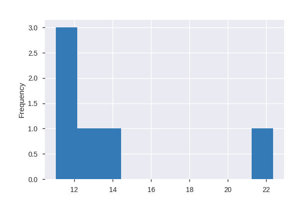

**Common Values**

| Value | Count | Frequency (%) |  |
| --- | --- | --- | --- |
| 11.64 | 2 | 3.0% |  |
| 13.42 | 1 | 1.5% |  |
| 22.36 | 1 | 1.5% |  |
| 11.03 | 1 | 1.5% |  |
| 12.25 | 1 | 1.5% |  |
| (Missing) | 60 | 90.9% |  |

**Extreme Values**

Minimum 5 values

| Value | Count | Frequency (%) |  |
| --- | --- | --- | --- |
| 11.03 | 1 | 1.5% |  |
| 11.64 | 2 | 3.0% |  |
| 12.25 | 1 | 1.5% |  |
| 13.42 | 1 | 1.5% |  |
| 22.36 | 1 | 1.5% |  |

Maximum 5 values

| Value | Count | Frequency (%) |  |
| --- | --- | --- | --- |
| 11.03 | 1 | 1.5% |  |
| 11.64 | 2 | 3.0% |  |
| 12.25 | 1 | 1.5% |  |
| 13.42 | 1 | 1.5% |  |
| 22.36 | 1 | 1.5% |  |

Glucagon  
Numeric

| Distinct count | 6 |
| --- | --- |
| Unique (%) | 9.1% |
| Missing (%) | 90.9% |
| Missing (n) | 60 |
| Infinite (%) | 0.0% |
| Infinite (n) | 0 |

| Mean | 10.2 |
| --- | --- |
| Minimum | 8.9 |
| Maximum | 12.05 |
| Zeros (%) | 0.0% |

Toggle details

**Statistics**

Quantile statistics

| Minimum | 8.9 |
| --- | --- |
| 5-th percentile | 9.07 |
| Q1 | 9.58 |
| Median | 9.905 |
| Q3 | 10.703 |
| 95-th percentile | 11.753 |
| Maximum | 12.05 |
| Range | 3.15 |
| Interquartile range | 1.1225 |

Descriptive statistics

| Standard deviation | 1.1241 |
| --- | --- |
| Coef of variation | 0.1102 |
| Kurtosis | 0.3506 |
| Mean | 10.2 |
| MAD | 0.84667 |
| Skewness | 0.83335 |
| Sum | 61.2 |
| Variance | 1.2636 |
| Memory size | 656.0 B |

**Histogram**

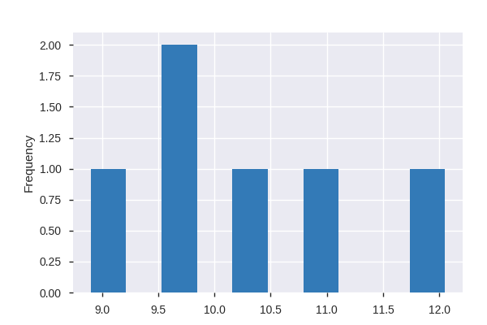

**Common Values**

| Value | Count | Frequency (%) |  |
| --- | --- | --- | --- |
| 9.58 | 2 | 3.0% |  |
| 12.05 | 1 | 1.5% |  |
| 8.9 | 1 | 1.5% |  |
| 10.23 | 1 | 1.5% |  |
| 10.86 | 1 | 1.5% |  |
| (Missing) | 60 | 90.9% |  |

**Extreme Values**

Minimum 5 values

| Value | Count | Frequency (%) |  |
| --- | --- | --- | --- |
| 8.9 | 1 | 1.5% |  |
| 9.58 | 2 | 3.0% |  |
| 10.23 | 1 | 1.5% |  |
| 10.86 | 1 | 1.5% |  |
| 12.05 | 1 | 1.5% |  |

Maximum 5 values

| Value | Count | Frequency (%) |  |
| --- | --- | --- | --- |
| 8.9 | 1 | 1.5% |  |
| 9.58 | 2 | 3.0% |  |
| 10.23 | 1 | 1.5% |  |
| 10.86 | 1 | 1.5% |  |
| 12.05 | 1 | 1.5% |  |

Insulin  
Highly correlated

*This variable is highly correlated with `C-Peptide` and should be ignored for analysis*

| Correlation | 0.98839 |
| --- | --- |

GLP-1 Active  
Constant

*This variable is constant and should be ignored for analysis*

| Constant value |  |
| --- | --- |

Leptin  
Constant

*This variable is constant and should be ignored for analysis*

| Constant value |  |
| --- | --- |

# Correlations

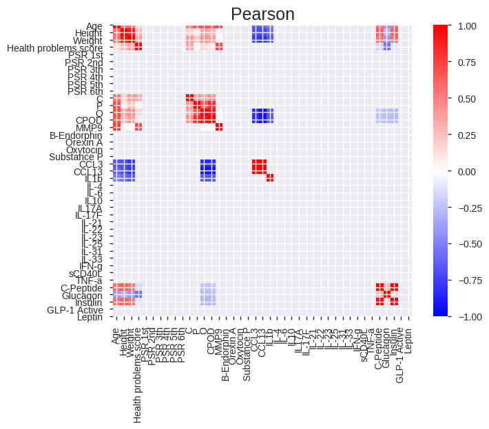

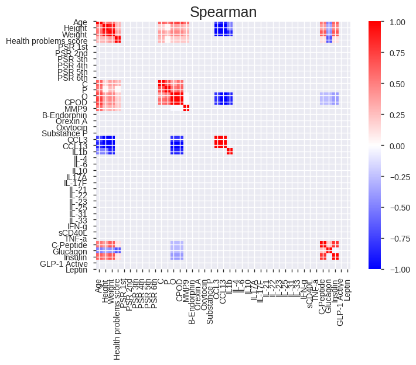

# Sample

| Sample | Age | Age group | Gender | Height | Weight | BMI | BMI group | Smoke habits | Alcool habits | Menopause | Anticonceptionals | Blood type | RH type | Hipertension | Diabetes | Cardiac | Blood | Liver | Stomach | Kidney | Other diseases | Allergy | Radio or Cheical Therapy | Health problems score | Regular medication | Medication | Treatment last 30 days | Antibiotic | Diet type | … |
| --- | --- | --- | --- | --- | --- | --- | --- | --- | --- | --- | --- | --- | --- | --- | --- | --- | --- | --- | --- | --- | --- | --- | --- | --- | --- | --- | --- | --- | --- | --- |
| D1122 | 10 | <13 | Male | 138.0 | 31.0 | 1.627.809.284 | Underweight | No | No | Man | Man | NaN | NaN | No | No | No | No | No | No | No | NaN | No | No | 0 | No | NaN | NaN | NaN | Other | … |
| D1127 | 7 | <13 | Female | 126.0 | 32.0 | 2.015.621.063 | Normal weight | No | No | No | NaN | NaN | NaN | No | No | No | No | No | No | No | NaN | No | No | 0 | No | NaN | NaN | NaN | NaN | … |
| D1132 | 8 | <13 | Female | 127.0 | 34.0 | 2.108.004.216 | Normal weight | No | No | No | NaN | NaN | NaN | No | No | No | No | No | No | No | NaN | No | No | 0 | No | NaN | NaN | NaN | NaN | … |
| D1138 | 16 | 13-24 | Female | 164.0 | 59.0 | -2.101.332.555 | Normal weight | No | No | No | NaN | NaN | NaN | No | No | No | No | No | No | No | NaN | No | No | 0 | No | NaN | NaN | NaN | NaN | … |
| D1143 | 19 | 13-24 | Female | 162.0 | 49.0 | 1.867.093.431 | Normal weight | No | Yes | No | Yes | NaN | NaN | No | No | No | No | NaN | No | No | No | No | No | 0 | No | NaN | NaN | NaN | Other | … |